# Exploratory Plots

Michael Haupt

5/7/2017

# Set Up

```r
library(ggplot2)
library(dplyr)
library(ggthemes)
library(tibble)

## Setting up Data
setwd("/Users/shilpasure/Documents/Grad School/Columbia/Spring 2017/Data Visualization/final-project-team-unemployed")

d <- read.csv("June 10-July 12, 2015 - Gaming, Jobs and Broadband - CSV.csv")

## Relabeling responses into Factors
d$job4 <- ifelse(d$job4 > 8, NA, d$job4)
d$job4[d$job4 == 1] <- "Friends and Family"
d$job4[d$job4 == 2] <- "Acquaintances"
d$job4[d$job4 == 3] <- "Professional Connections"
d$job4[d$job4 == 4] <- "Online Resources"
d$job4[d$job4 == 5] <- "Govt or Private Employment Agencies"
d$job4[d$job4 == 6] <- "Ads in Print"
d$job4[d$job4 == 7] <- "Job Fairs / Conferences"
d$job4[d$job4 == 8] <- "Other"

## Converting Don't Know responses into NA
d$job3a <- ifelse(d$job3a > 2, NA, d$job3a)
d$job3b <- ifelse(d$job3b > 2, NA, d$job3b)
d$job3c <- ifelse(d$job3c > 2, NA, d$job3c)
d$job3d <- ifelse(d$job3d > 2, NA, d$job3d)
d$job3e <- ifelse(d$job3e > 2, NA, d$job3e)
d$job3f <- ifelse(d$job3f > 2, NA, d$job3f)
d$job3g <- ifelse(d$job3g > 2, NA, d$job3g)
d$job3h <- ifelse(d$job3h > 2, NA, d$job3h)

## Changing Binary into 0 - 1 (currently 1 -2)
d$job3a <- ifelse(d$job3a == 1, 1, 0)
d$job3b <- ifelse(d$job3b == 1, 1, 0)
d$job3c <- ifelse(d$job3c == 1, 1, 0)
d$job3d <- ifelse(d$job3d == 1, 1, 0)
d$job3e <- ifelse(d$job3e == 1, 1, 0)
d$job3f <- ifelse(d$job3f == 1, 1, 0)
d$job3g <- ifelse(d$job3g == 1, 1, 0)
d$job3h <- ifelse(d$job3h == 1, 1, 0)

## Creating Age Ranges (Factors)
d$age_range <- ifelse(d$age >= 18 & d$age < 25, "18-24", d$age)
d$age_range <- ifelse(d$age >= 25 & d$age < 35, "25-34", d$age_range)
d$age_range <- ifelse(d$age >= 35 & d$age < 45, "35-44", d$age_range)
d$age_range <- ifelse(d$age >= 45 & d$age < 55, "45-54", d$age_range)
d$age_range <- ifelse(d$age >= 55 & d$age < 65, "55-64", d$age_range)
d$age_range <- ifelse(d$age >= 65, "65+", d$age_range)

## Subsetting dataset - Removing NAs
sub <- as.data.frame(na.omit(d[, c("job4", "age_range")]))
colnames(sub)[1] <- "job4"
sub$job4 <- factor(sub$job4, levels = c("Other", "Govt or Private Employment Agencies", "Ads in Print", "Online Resources", "Job Fairs / Conferences", "Professional Connections", "Acquaintances", "Friends and Family"))

## Use Social Media - Research Job by Age
d$snsjob1a[d$snsjob1a >= 8] <- NA
d$snsjob1b[d$snsjob1b >= 8] <- NA
d$snsjob1c[d$snsjob1c >= 8] <- NA

## Graph 2 - Use Social Media to Research Jobs?  ---------------------
# Setting up Dataset
sub2 <- as.data.frame(na.omit(d[, c("snsjob1a", "age", "age_range")]))
colnames(sub2)[1] <- "snsjob1a"
sub2$snsjob1a <- as.factor(sub2$snsjob1a)
sub2$snsjob1a <- ifelse(sub2$snsjob1a == 1, "Yes", "No")

## Making Yes/No variable into Binary
sub2$binary <- ifelse(sub2$snsjob1a == "Yes", 1, 0)

## Creating average percent for age range
avg_age <- sub2 %>%
  group_by(age_range) %>%
  summarize(avg_age = mean(binary))
```

For this plot we wanted to see which job seeking methods that respondents believed were most important. We originally created a bar graph to display the percentage of responses that each method received. While we did like this graph on its own, we decided to combine it with another graph that had a similar format except that it asked respondents to write down which methods that they used during their last job search. We figured since they were similar questions, it would be more efficient to combine them together. Additionally, this made it easier to directly compare what people think is most important for the job search vs. what they actually do.

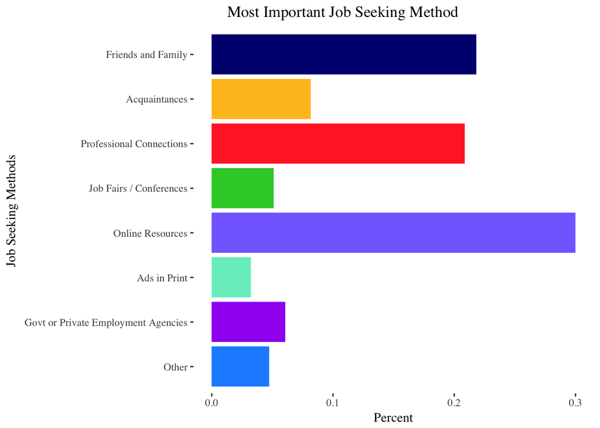

```r
# Exploratory Plot 1 -------------------------------------------
## Barplot showing Job Seeking Methods by Percent
sub %>%
  ggplot(aes(x = job4, fill = job4)) +
  geom_bar(aes(y=..count../sum(..count..))) +
  coord_flip() +
  xlab("Job Seeking Methods") +
  ylab("Percent") +
  ggtitle("Most Important Job Seeking Method") +
  scale_fill_manual(values = c("dodgerblue", "purple", "aquamarine2", "lightslateblue", "limegreen", "firebrick1", "goldenrod1", "navy")) +
  theme_tufte() +
  theme(legend.position = "none", plot.title = element_text(hjust = .2))
```

```r
# ----------------------------------------
```

We originally liked this graph on its own as well. However, since we had another graph that was similar in format but asked respondents if they applied for jobs using social media, we chose to combine these two graphs together (similarly to what we did with the previous graphs). This way it was more efficient and made it easier to compare the responses between both questions.

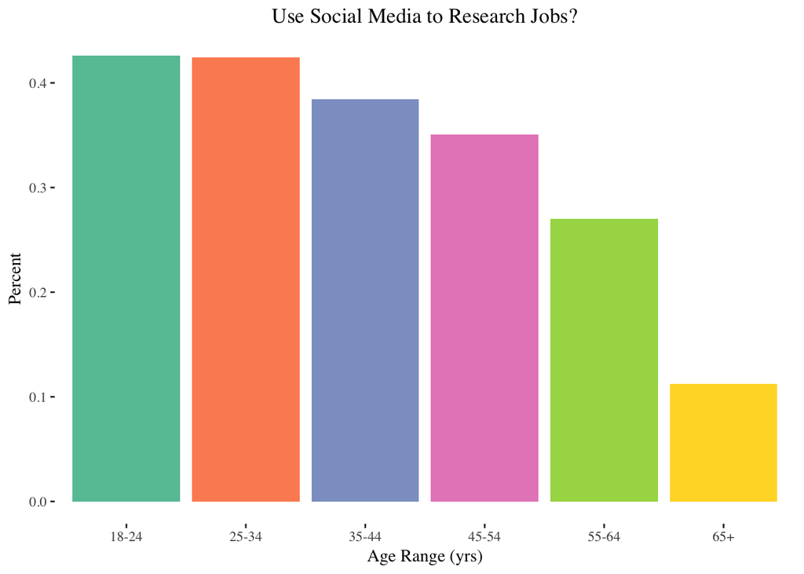

```r
# Exploratory Plot 2 ----------------------------------------------
## Bar Chart - Using Social Media to Research Jobs by Age Range
avg_age %>%
  ggplot(aes(x = age_range, y = avg_age, fill = age_range)) +
  geom_bar(stat = "identity") +
  xlab("Age Range (yrs)") +
  ylab("Percent") +
  ggtitle("Use Social Media to Research Jobs?") +
  theme_tufte() +
  scale_fill_brewer(palette = "Set2") +
  theme(legend.position = "none", plot.title = element_text(hjust = .5))
```